# enerscape

# Energy Lanscapes for Walking People

As of enerscape 1.2 I implemented the energy cost model for walking people from Looney et al. (2019). This can be calculated using the `humanscape()` function. The arguments are the same as for `enerscape()`, except for an additional argument `v`, which is the walking speed (m/s). If `v` is not specified, it is assumed to be `v = 1.39`, which optimize the energy costs.

[figure not shown]

```r
en <- lapply(
  seq(0.5, 2.5, by = .5),
  \(v) humanscape(dem, 10, v = v, neigh = 4, unit = "kcal")
)
```

```
#> DEM is assumed to have planar CRS in meters.
#> DEM is assumed to have planar CRS in meters.
#> DEM is assumed to have planar CRS in meters.
#> DEM is assumed to have planar CRS in meters.
#> DEM is assumed to have planar CRS in meters.
```

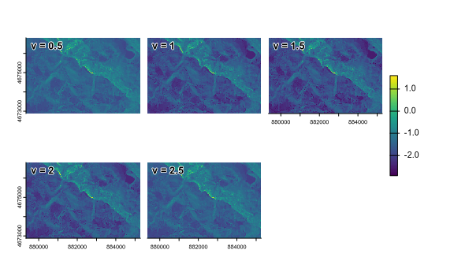

```r
en <- rast(en)
names(en) <- paste0("v = ", seq(0.5, 2.5, by = .5))
en_log <- log(en)
panel(en_log, nc = 3)
```

# Changelog

## 1.2.0

Add `humanscape()` to calculate energy costs of walking people.

Updating documentation.

## 1.1.0

This follows a correction on the Pontzer model: https://doi.org/10.1098/rsbl.2023.0492.

## 1.0.0

This follows the transfer of functionalists of old GIS packages to *terra*, with *rgdal*, *rgeos* scheduled to be retired in 2023: https://r-spatial.org/r/2022/04/12/evolution.html. I removed dependencies on *gDistance*, *raster*, *sp*, *rgeos*, and *rgdal*.

Energy landscapes are now calculated using a zonal (kernel) based method, implemented in C++ functions. This is faster that previous versions, but it does not return the transition matrix or the conductance matrix. Because of this, least cost paths functions are not supported any more. Instead, use circuitscape or omniscape; see *circuitscape_skeleton()* and *omniscape_skeleton()* to generate the initialization files to run in Julia.

The cyclist model is also not supported any more; custom models must be written in the C++ functions. I plan to add a customizable function soon to do that.

# References

Pontzer, H. (2016). A unified theory for the energy cost of legged locomotion. Biology letters, 12(2), 20150935.

Berti, E., Davoli, M., Buitenwerf, R., Dyer, A., Hansen, O. L., Hirt, M., … & Vollrath, F. (2022). The r package enerscape: A general energy landscape framework for terrestrial movement ecology. Methods in Ecology and Evolution, 13(1), 60-67.

Looney, D. P., Santee, W. R., Hansen, E. O., Bonventre, P. J., Chalmers, C. R., & Potter, A. W. (2019). Estimating energy expenditure during level, uphill, and downhill walking. Med. Sci. Sports Exerc., 51(9), 1954-1960.